# final

Iris

December 16, 2014

I created a set of functions that take in starting parameters for a Lotka-Volterra model of two microbes growing and competing in one host, and return the expected average population size of the two microbes after a user-identified number of host generations. Each microbe has an intrinsic rate of increase (the rate at which they would breed absent of any resource competition), a carrying capacity within the host, and a degree to which the population of the other microbe affects their growth rate. I also allow the user to set the number of hosts available to the microbe, and the number of generations the microbes undergo per host generation.

The function is:

microbe population at time t = population at t-1 * exp(intrinsic growth rate * (1-(population at t - competition term * population of other microbe at time t)))

At low population levels of both microbes, the competition term will be low, and the population will grow at close to its fundamental rate of increase. At higher population levels, competition will reduce the rate to growth to zero. If the population excedes its carrying capacity, it will reduce in size.

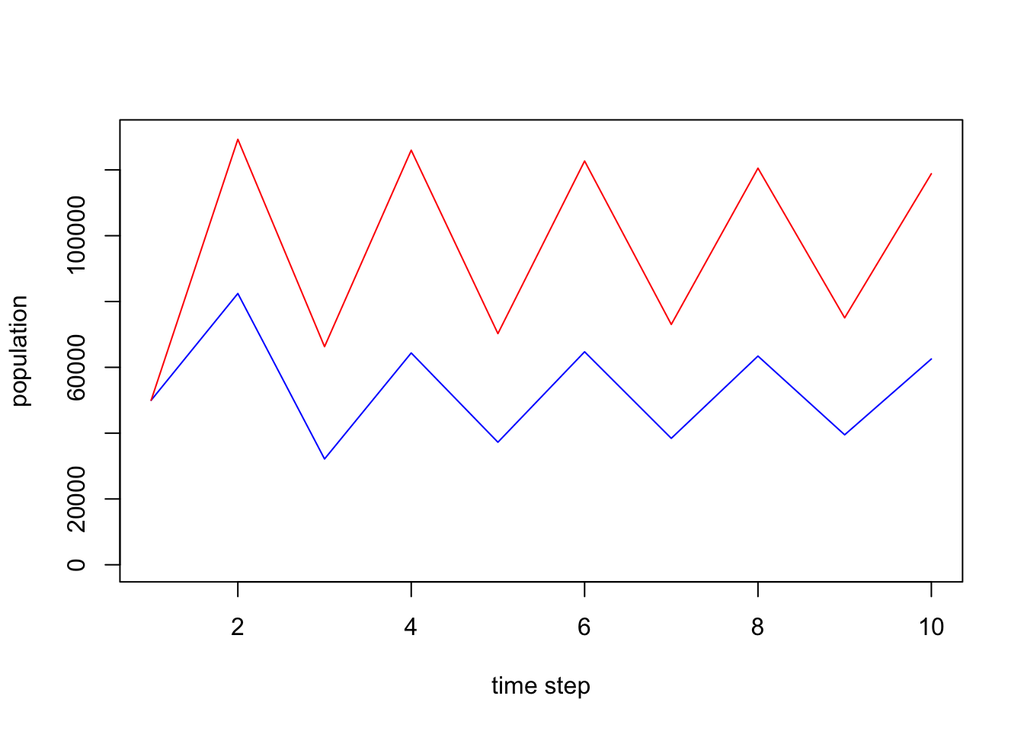

Due to competition between the organisms, their population levels show fluctuation over time within a host. In order to model transimission between hosts, I used a second function with two new parameters, which determine the percentage of each microbe’s population that is transmitted to its offspring. I model the population with each host having exactly one offspring. Each new host starts out with excatly 1000 individual microbes, with the makeup of that seed population determined by the microbe’s relative frequency in the parent multiplied by that microbe’s transmission probability.

To make the overall function as quick and user-friendly as possible, I created a function that takes in the user’s desired range of competition coeffiecients (ranging from 0 to 1), transmission probabilities (also from zero to 1), and intrinsic rates of growth (unbounded, whole numbers), and makes a matrix of each unique combination of parameters.

Finally, I combine the within-host and transmission functions into one large model function, and apply that function to each user-defined parameter combination. The function returns the average population level of each microbe at each parameter combination over N host generations.

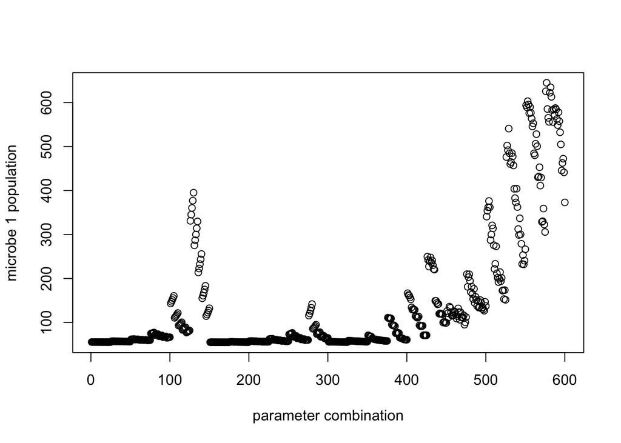

Over the course of the several generations modeled in the function, the populations of the two microbes oscellate around their shared carrying capacity, such that determining the average population size of microbe1 means that the average population size of microbe 2 will be the carrying capacity minus the population of microbe 1. As such, I made a function to return the parameter estimates that would produce a given observed population size of microbe 1. The function works by finding the k nearest neighbors of the proposed point, and returning an inverse distance weighted average of the parameters that produced the k neighboring points. The function works only for interpolation. If the point of interest is outside the points generated by the simulation, the reconstructed parameter values will be highly biased.

```
## [1] 0.50 0.25 0.20 2.00
```